# Working through the StatLearn MetaAnalysis

Alexis Black & Christina Bergmann

2/1/2017

## Set-up

- The first thing to do is get the workspace set up, and data loaded and cleaned up

```
## Loading 'metafor' package (version 1.9-9). For an overview
## and introduction to the package please type: help(metafor).
```

## Collapse over non-independent rows

When two or more rows contain data from the same infants, those are no longer independent. To make up for this, we take the median (which if there are 2 rows defaults to the average) effect size. Note that analyses based on t-values (see replicability analyses) should check whether this way we lose significant t-values.

## Starting with Direct Replications

We defined a direct replication as any study that used a continuous stream that could only be segmented via transitional probabilities (i.e. no other cue either in tandem with or in contrast to TPs), and where there was no fundamental change to the experimental protocol. For example, experiments that consist of a priming period prior to familiarization were not included as direct replications, nor were experiments that invovled a test using novel tokens or sentence frames, rather than test items extracted directly from the speech stream.

```r
#### Create subsets ####

# direct replications only, as coded in the spreadsheet

db_DR <- db %>% filter(DirectRep == "yes")
```

```r
#### Random effect model direct replications ####

rma_DR <- rma.mv(g_calc, g_var_calc, data = db_DR, random = ~1 | short_cite)

summary(rma_DR)
```

```
##
## Multivariate Meta-Analysis Model (k = 17; method: REML)
##
##   logLik  Deviance       AIC       BIC      AICc
##  -4.8185    9.6371   13.6371   15.1822   14.5601
##
## Variance Components:
##
##             estim    sqrt  nlvls  fixed      factor
## sigma^2    0.0732  0.2706     10     no  short_cite
##
## Test for Heterogeneity:
## Q(df = 16) = 70.9725, p-val < .0001
##
## Model Results:
##
## estimate       se     zval     pval    ci.lb    ci.ub
##   0.2055   0.0965   2.1289   0.0333   0.0163   0.3946        *
##
## ---
## Signif. codes:  0 '***' 0.001 '**' 0.01 '*' 0.05 '.' 0.1 ' ' 1
```

# + Forest

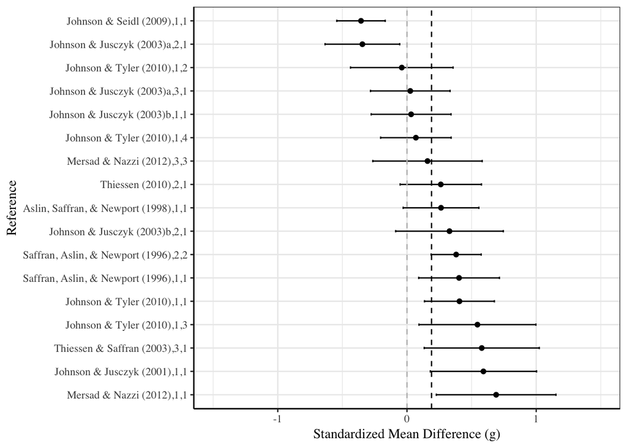

```r
#forest(rma_DR)

##Borrowing some code to make this a ggplot:
#https://sakaluk.wordpress.com/2016/02/16/7-make-it-pretty-plots-for-met#a-analysis/

#Rename a bunch of things for ease
dat=db_DR
dat <-
  dat %>%
  rename(cite = short_cite,
         yi = g_calc,
         vi = g_var_calc)

#Reorder bibliographic info based on value of g (yi), so effect sizes can be plotted in descending order

dat <-
  dat %>%
  select(cite, expt_num, same_infant, mean_age_1, yi, vi) %>%
  mutate(study_ref = paste(cite, expt_num, same_infant, sep=',')) %>%
  arrange(desc(yi))

#Get standard errors from variances
dat$se = sqrt(dat$vi)

#Calculate 95% CI values
dat$lowerci = (-1.96*dat$se)+dat$yi
dat$upperci = (1.96*dat$se)+dat$yi

#Themes and plot
apatheme=theme_bw()+
  theme(#panel.grid.major=element_blank(),
        #panel.grid.minor=element_blank(),
        #panel.border=element_blank(),
        axis.line=element_line(),
        text=element_text(family='Times'),
        legend.position='none')
p=
  ggplot(dat, aes(y=reorder(study_ref, -yi), x=yi, xmin=lowerci, xmax=upperci))+
  #Add data points and color them black
  geom_point(color = 'black')+
  #Add 'special' points for the summary estimates, by making them diamond shaped
#  geom_point(data=subset(dat, tester=='Summary'), color='black', shape=18, size=4)+
  #add the CI error bars
  geom_errorbarh(height=.1)+
  #Specify the limits of the x-axis and relabel it to something more meaningful
  scale_x_continuous(limits=c(-1.5,1.5), name='Standardized Mean Difference (g)')+
  #Give y-axis a meaningful label
  ylab('Reference')+
  #Add a vertical dashed line indicating an effect size of zero, for reference
  geom_vline(xintercept=0, color='grey', linetype='dashed')+
  #Add a vertical line to show mean effect
  geom_vline(xintercept=0.19, color='black', linetype='dashed')+
  #Create sub-plots (i.e., facets) based on levels of setting
  #And allow them to have their own unique axes (so authors don't redundantly repeat)
  #facet_grid(setting~., scales= 'free', space='free')+
  #Apply my APA theme
  apatheme

p
```

```r
ggsave("figures/ForestPlot_DR.png", p)
```

# + Funnel

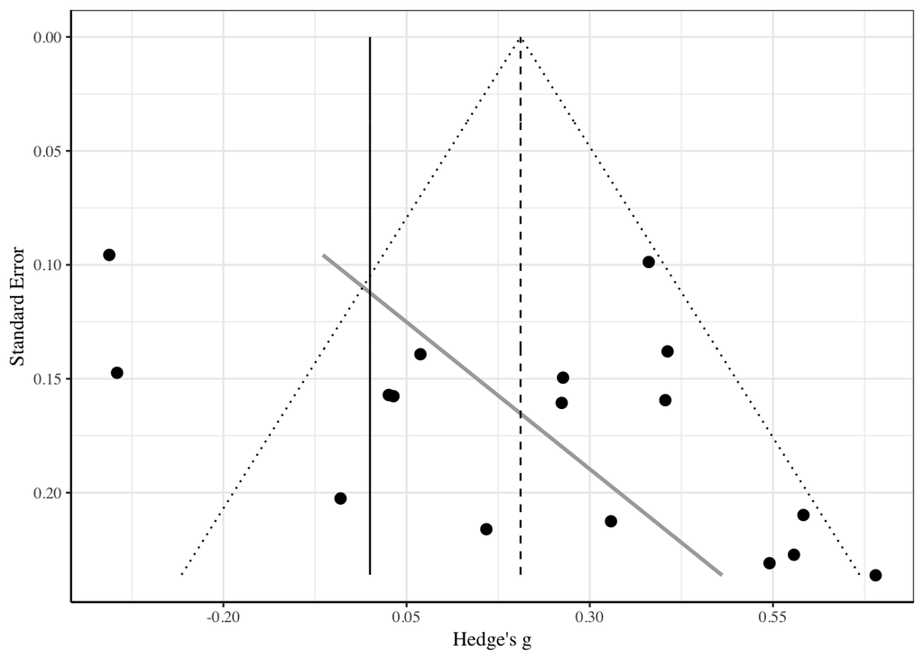

```r
### This code is from:
### https://sakaluk.wordpress.com/2016/02/16/7-make-it-pretty-plots-for-met#a-analysis/
### Store the meta-analytic estimate and its standard error from whatever
### model you run (substitute your own values) rma_DR
estimate = 0.2055
se = 0.0965

# Store a vector of values that spans the range from 0 to the max value of
# impression (standard error) in your dataset. Make the increment (the final
# value) small enough (I choose 0.001) to ensure your whole range of data is
# captured
se.seq = seq(0, max(dat$se), 0.001)

# Now, compute vectors of the lower-limit and upper limit values for the 95%
# CI region, using the range of SE that you generated in the previous step,
# and the stored value of your meta-analytic estimate.
ll95 = estimate - (1.96 * se.seq)
ul95 = estimate + (1.96 * se.seq)

# You can do this for a 99% CI region too
ll99 = estimate - (3.29 * se.seq)
ul99 = estimate + (3.29 * se.seq)

# And finally, do the same thing except now calculating the confidence
# interval for your meta-analytic estimate based on the stored value of its
# standard error
meanll95 = estimate - (1.96 * se)
meanul95 = estimate + (1.96 * se)

# Now, smash all of those calculated values into one data frame (called
# 'dfCI'). You might get a warning about '...row names were found from a
# short variable...' You can ignore it.
dfCI = data.frame(ll95, ul95, ll99, ul99, se.seq, estimate, meanll95, meanul95)

# Now we can actually make the funnel plot. Using your original data-frame,
# map standard error to your x-axis (for now) and Zr to your y-axis
fp = ggplot(aes(x = se, y = yi), data = dat) + # Regression line for the FP asymmetry
geom_smooth(aes(x = se, y = yi), method = "lm", colour = "darkgrey", alpha = 0.5,
    se = FALSE, data = dat) + # Add your data-points to the scatterplot
geom_point(size = 2.5, colour = "black") + # Give the x- and y- axes informative labels
xlab("Standard Error") + ylab("Hedge's g") + # Now using the 'dfCI' data-frame we created, plot dotted lines
# corresponding to the lower and upper limits of your 95% CI region And
# dashed lines corresponding to your 99% CI region Add lines corresponding
# to 0 and estimate
geom_line(aes(x = se.seq, y = 0), linetype = "solid", data = dfCI) + geom_line(aes(x = se.seq,
    y = estimate), linetype = "dashed", data = dfCI) + geom_line(aes(x = se.seq,
    y = ll95), linetype = "dotted", data = dfCI) + geom_line(aes(x = se.seq,
    y = ul95), linetype = "dotted", data = dfCI) + # geom_line(aes(x = se.seq, y = ll99), linetype = 'dashed', data = dfCI) +
# geom_line(aes(x = se.seq, y = ul99), linetype = 'dashed', data = dfCI) +
# Now plot dotted lines corresponding to the 95% CI of your meta-analytic
# estimate geom_segment(aes(x = min(se.seq), y = meanll95, xend =
# max(se.seq), yend = meanll95), linetype='dotted', data=dfCI) +
# geom_segment(aes(x = min(se.seq), y = meanul95, xend = max(se.seq), yend =
# meanul95), linetype='dotted', data=dfCI) + Reverse the x-axis ordering
# (se) so that the tip of the funnel will appear at the top of the figure
# once we swap the x- and y-axes...
scale_x_reverse() + # Specify the range and interval for the tick-marks of the y-axis (Zr);
# Choose values that work for you based on your data
scale_y_continuous(breaks = seq(-0.45, 0.8, 0.25)) + # And now we flip the axes so that SE is on y- and Zr is on x-
coord_flip() + # Finally, apply my APA-format theme (see code at end of post). You could,
# alternatively, specify theme_bw() instead.
apatheme

# Call the pretty funnel plot
fp
```

```r
ggsave("figures/FunnelPlot_DR.pdf")
# This is the 'classical' plot from the metafor package funnel(rma_DR)
```

## Moderators

We look first at age (do infants switch preference or improve with age?), then stimulus type (artificial vs natural speech)

```r
# The age effect: does infant age affect the slope?
rma_age_DR <- rma.mv(g_calc, g_var_calc, mods = age.C, data = db_DR, random = ~1 |
    short_cite)
summary(rma_age_DR)
```

```
##
## Multivariate Meta-Analysis Model (k = 17; method: REML)
##
##   logLik  Deviance       AIC       BIC      AICc
##  -5.0065   10.0131   16.0131   18.1372   18.1949
##
## Variance Components:
##
##             estim    sqrt  nlvls  fixed      factor
## sigma^2    0.0729  0.2699     10     no  short_cite
##
## Test for Residual Heterogeneity:
## QE(df = 15) = 63.7937, p-val < .0001
##
## Test of Moderators (coefficient(s) 2):
## QM(df = 1) = 0.5670, p-val = 0.4515
##
## Model Results:
##
##          estimate      se     zval    pval    ci.lb   ci.ub
## intrcpt    0.2021  0.0964   2.0958  0.0361   0.0131  0.3911  *
## mods      -0.0011  0.0015  -0.7530  0.4515  -0.0041  0.0018
##
## ---
## Signif. codes:  0 '***' 0.001 '**' 0.01 '*' 0.05 '.' 0.1 ' ' 1
```

```r
# Look at Stimulus Type, first do a 'typical' moderator test
rma_stimuli_DR = rma.mv(g_calc, g_var_calc, mods = ~factor(StimuliType), data = db_DR,
    random = ~1 | short_cite)
summary(rma_stimuli_DR)
```

```
##
## Multivariate Meta-Analysis Model (k = 17; method: REML)
##
##   logLik  Deviance       AIC       BIC      AICc
##  -3.0782    6.1564   12.1564   14.2805   14.3382
##
## Variance Components:
##
##             estim    sqrt  nlvls  fixed      factor
## sigma^2    0.0397  0.1993     10     no  short_cite
##
## Test for Residual Heterogeneity:
## QE(df = 15) = 39.1307, p-val = 0.0006
##
## Test of Moderators (coefficient(s) 2):
## QM(df = 1) = 5.1524, p-val = 0.0232
##
## Model Results:
##
##                       estimate      se     zval    pval    ci.lb    ci.ub
## intrcpt                 0.3379  0.0997   3.3882  0.0007   0.1424   0.5334
## factor(StimuliType)1   -0.3536  0.1558  -2.2699  0.0232  -0.6589  -0.0483
##
## intrcpt               ***
## factor(StimuliType)1    *
##
## ---
## Signif. codes:  0 '***' 0.001 '**' 0.01 '*' 0.05 '.' 0.1 ' ' 1
```

```r
# Now remove intercept to see which subset is different from 0
rma_stimuli_DR_1 = rma.mv(g_calc, g_var_calc, mods = ~factor(StimuliType) -
    1, data = db_DR, random = ~1 | short_cite)
summary(rma_stimuli_DR_1)
```

```
##
## Multivariate Meta-Analysis Model (k = 17; method: REML)
##
##   logLik  Deviance       AIC       BIC      AICc
##  -3.0782    6.1564   12.1564   14.2805   14.3382
##
## Variance Components:
##
##             estim    sqrt  nlvls  fixed      factor
## sigma^2    0.0397  0.1993     10     no  short_cite
##
## Test for Residual Heterogeneity:
## QE(df = 15) = 39.1307, p-val = 0.0006
##
## Test of Moderators (coefficient(s) 1,2):
## QM(df = 2) = 11.4971, p-val = 0.0032
##
## Model Results:
##
##                       estimate      se     zval    pval    ci.lb   ci.ub
## factor(StimuliType)0    0.3379  0.0997   3.3882  0.0007   0.1424  0.5334
## factor(StimuliType)1   -0.0157  0.1197  -0.1311  0.8957  -0.2502  0.2189
##
## factor(StimuliType)0  ***
## factor(StimuliType)1
##
## ---
## Signif. codes:  0 '***' 0.001 '**' 0.01 '*' 0.05 '.' 0.1 ' ' 1
```

```r
# Follow-up: Subsets, easier to interpret and write down, conclusions are
# the same as the previous analysis without intercept

# artificial only, n=11
rma_stimuli_DR_subset0 = rma.mv(g_calc, g_var_calc, data = db_DR, subset = (StimuliType ==
    0), random = ~1 | short_cite)
summary(rma_stimuli_DR_subset0)
```

```
##
## Multivariate Meta-Analysis Model (k = 11; method: REML)
##
##   logLik  Deviance       AIC       BIC      AICc
##   1.8369   -3.6739    0.3261    0.9313    2.0404
##
## Variance Components:
##
##             estim    sqrt  nlvls  fixed      factor
## sigma^2    0.0000  0.0000      6     no  short_cite
##
## Test for Heterogeneity:
## Q(df = 10) = 12.9838, p-val = 0.2246
##
## Model Results:
##
## estimate       se     zval     pval    ci.lb    ci.ub
##   0.3197   0.0481   6.6402   <.0001   0.2253   0.4141      ***
##
## ---
## Signif. codes:  0 '***' 0.001 '**' 0.01 '*' 0.05 '.' 0.1 ' ' 1
```

```r
# natural only, n=6
rma_stimuli_DR_subset1 = rma.mv(g_calc, g_var_calc, data = db_DR, subset = (StimuliType ==
    1), random = ~1 | short_cite)
summary(rma_stimuli_DR_subset1)
```

```
##
## Multivariate Meta-Analysis Model (k = 6; method: REML)
##
##   logLik  Deviance       AIC       BIC      AICc
##  -2.4117    4.8234    8.8234    8.0423   14.8234
##
## Variance Components:
##
##             estim    sqrt  nlvls  fixed      factor
## sigma^2    0.1340  0.3661      4     no  short_cite
##
## Test for Heterogeneity:
## Q(df = 5) = 26.1468, p-val < .0001
##
## Model Results:
##
## estimate       se     zval     pval    ci.lb    ci.ub
##   0.0220   0.1956   0.1125   0.9104  -0.3613   0.4054
##
## ---
## Signif. codes:  0 '***' 0.001 '**' 0.01 '*' 0.05 '.' 0.1 ' ' 1
```

# The whole data-set

I’ll execute the same steps as above, but hide the code for aesthetics.

```
##
## Multivariate Meta-Analysis Model (k = 68; method: REML)
##
##   logLik  Deviance       AIC       BIC      AICc
## -85.8727  171.7454  175.7454  180.1548  175.9329
##
## Variance Components:
##
##             estim    sqrt  nlvls  fixed      factor
## sigma^2    0.0416  0.2039     20     no  short_cite
##
## Test for Heterogeneity:
## Q(df = 67) = 334.2630, p-val < .0001
##
## Model Results:
##
## estimate       se     zval     pval    ci.lb    ci.ub
##   0.0867   0.0522   1.6614   0.0966  -0.0156   0.1891        .
##
## ---
## Signif. codes:  0 '***' 0.001 '**' 0.01 '*' 0.05 '.' 0.1 ' ' 1
```

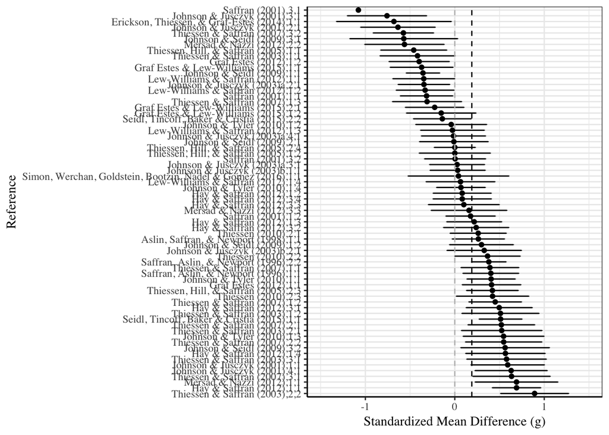

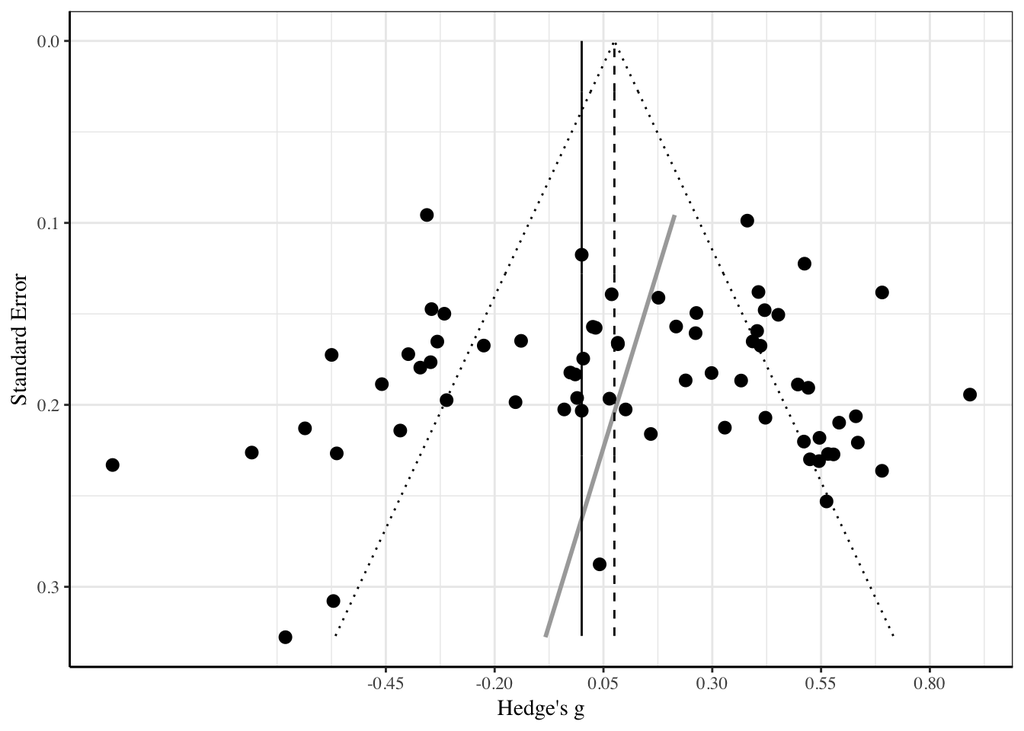

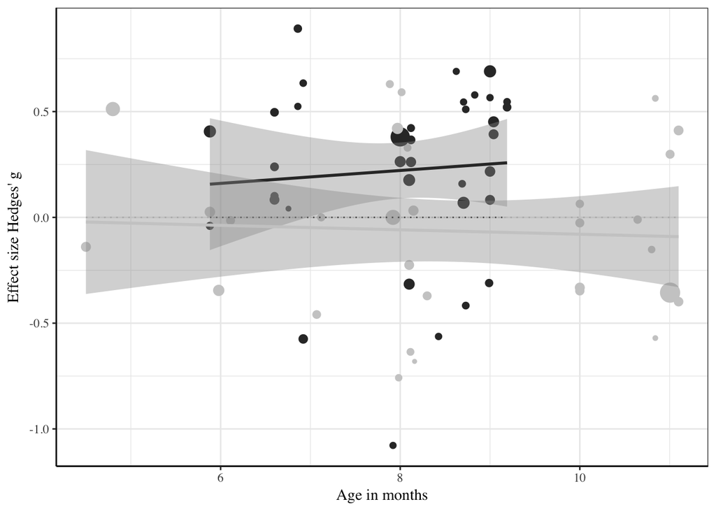

## Moderators, with the whole data set

# Age

First age, now we have enough data to also look at the quadratic term.

```
##
## Multivariate Meta-Analysis Model (k = 68; method: REML)
##
##   logLik  Deviance       AIC       BIC      AICc
## -86.0831  172.1662  178.1662  184.7352  178.5533
##
## Variance Components:
##
##             estim    sqrt  nlvls  fixed      factor
## sigma^2    0.0462  0.2150     20     no  short_cite
##
## Test for Residual Heterogeneity:
## QE(df = 66) = 326.6518, p-val < .0001
##
## Test of Moderators (coefficient(s) 2):
## QM(df = 1) = 0.2794, p-val = 0.5971
##
## Model Results:
##
##          estimate      se    zval    pval    ci.lb   ci.ub
## intrcpt    0.0871  0.0545  1.5970  0.1103  -0.0198  0.1939
## mods       0.0004  0.0008  0.5286  0.5971  -0.0011  0.0019
##
## ---
## Signif. codes:  0 '***' 0.001 '**' 0.01 '*' 0.05 '.' 0.1 ' ' 1
```

```
##
## Multivariate Meta-Analysis Model (k = 68; method: REML)
##
##   logLik  Deviance       AIC       BIC      AICc
## -86.0240  172.0480  178.0480  184.6170  178.4351
##
## Variance Components:
##
##             estim    sqrt  nlvls  fixed      factor
## sigma^2    0.0417  0.2042     20     no  short_cite
##
## Test for Residual Heterogeneity:
## QE(df = 66) = 324.4361, p-val < .0001
##
## Test of Moderators (coefficient(s) 2):
## QM(df = 1) = 0.1147, p-val = 0.7348
##
## Model Results:
##
##          estimate      se     zval    pval    ci.lb   ci.ub
## intrcpt    0.0855  0.0524   1.6309  0.1029  -0.0172  0.1882
## mods      -0.0000  0.0000  -0.3387  0.7348  -0.0000  0.0000
##
## ---
## Signif. codes:  0 '***' 0.001 '**' 0.01 '*' 0.05 '.' 0.1 ' ' 1
```

# Stimulus Type

```
##
## Multivariate Meta-Analysis Model (k = 68; method: REML)
##
##   logLik  Deviance       AIC       BIC      AICc
## -81.5289  163.0577  169.0577  175.6267  169.4448
##
## Variance Components:
##
##             estim    sqrt  nlvls  fixed      factor
## sigma^2    0.0234  0.1531     20     no  short_cite
##
## Test for Residual Heterogeneity:
## QE(df = 66) = 288.8418, p-val < .0001
##
## Test of Moderators (coefficient(s) 2):
## QM(df = 1) = 10.9293, p-val = 0.0009
##
## Model Results:
##
##                       estimate      se     zval    pval    ci.lb    ci.ub
## intrcpt                 0.2280  0.0591   3.8598  0.0001   0.1122   0.3437
## factor(StimuliType)1   -0.2779  0.0841  -3.3059  0.0009  -0.4426  -0.1131
##
## intrcpt               ***
## factor(StimuliType)1  ***
##
## ---
## Signif. codes:  0 '***' 0.001 '**' 0.01 '*' 0.05 '.' 0.1 ' ' 1
```

```
##
## Multivariate Meta-Analysis Model (k = 68; method: REML)
##
##   logLik  Deviance       AIC       BIC      AICc
## -81.5289  163.0577  169.0577  175.6267  169.4448
##
## Variance Components:
##
##             estim    sqrt  nlvls  fixed      factor
## sigma^2    0.0234  0.1531     20     no  short_cite
##
## Test for Residual Heterogeneity:
## QE(df = 66) = 288.8418, p-val < .0001
##
## Test of Moderators (coefficient(s) 1,2):
## QM(df = 2) = 15.5944, p-val = 0.0004
##
## Model Results:
##
##                       estimate      se     zval    pval    ci.lb   ci.ub
## factor(StimuliType)0    0.2280  0.0591   3.8598  0.0001   0.1122  0.3437
## factor(StimuliType)1   -0.0499  0.0598  -0.8347  0.4039  -0.1672  0.0673
##
## factor(StimuliType)0  ***
## factor(StimuliType)1
##
## ---
## Signif. codes:  0 '***' 0.001 '**' 0.01 '*' 0.05 '.' 0.1 ' ' 1
```

```
##
## Multivariate Meta-Analysis Model (k = 38; method: REML)
##
##   logLik  Deviance       AIC       BIC      AICc
## -42.6196   85.2391   89.2391   92.4610   89.5921
##
## Variance Components:
##
##             estim    sqrt  nlvls  fixed      factor
## sigma^2    0.0259  0.1610     10     no  short_cite
##
## Test for Heterogeneity:
## Q(df = 37) = 158.4654, p-val < .0001
##
## Model Results:
##
## estimate       se     zval     pval    ci.lb    ci.ub
##   0.2276   0.0613   3.7150   0.0002   0.1075   0.3477      ***
##
## ---
## Signif. codes:  0 '***' 0.001 '**' 0.01 '*' 0.05 '.' 0.1 ' ' 1
```

```
##
## Multivariate Meta-Analysis Model (k = 30; method: REML)
##
##   logLik  Deviance       AIC       BIC      AICc
## -38.8785   77.7570   81.7570   84.4916   82.2185
##
## Variance Components:
##
##             estim    sqrt  nlvls  fixed      factor
## sigma^2    0.0202  0.1421     10     no  short_cite
##
## Test for Heterogeneity:
## Q(df = 29) = 130.3764, p-val < .0001
##
## Model Results:
##
## estimate       se     zval     pval    ci.lb    ci.ub
##  -0.0491   0.0568  -0.8643   0.3874  -0.1605   0.0623
##
## ---
## Signif. codes:  0 '***' 0.001 '**' 0.01 '*' 0.05 '.' 0.1 ' ' 1
```

# Additional cues

This requires a second thought. There are multiple experiments here that are intentionally testing whether additional cues supercede SL. This has been coded in two ways: cues that interfere with the TP structure, and cues that interfere with the Native language expectations. In many cases these will be the same (i.e. iambic stress interferes with the TP structure *because* it contradicts native language expectations).

For clarity, we focus for now on TP cue conflicts.

```r
# Look at additional cues
rma_cue = rma.mv(g_calc, g_var_calc, mods = ~factor(cue_conflict_TP), data = db,
    random = ~1 | short_cite)
summary(rma_cue)
```

```
##
## Multivariate Meta-Analysis Model (k = 68; method: REML)
##
##   logLik  Deviance       AIC       BIC      AICc
## -85.8947  171.7895  179.7895  188.4870  180.4561
##
## Variance Components:
##
##             estim    sqrt  nlvls  fixed      factor
## sigma^2    0.0415  0.2038     20     no  short_cite
##
## Test for Residual Heterogeneity:
## QE(df = 65) = 332.6208, p-val < .0001
##
## Test of Moderators (coefficient(s) 2,3):
## QM(df = 2) = 1.9310, p-val = 0.3808
##
## Model Results:
##
##                             estimate      se     zval    pval    ci.lb
## intrcpt                       0.1098  0.0661   1.6609  0.0967  -0.0198
## factor(cue_conflict_TP)no    -0.0100  0.0731  -0.1374  0.8907  -0.1534
## factor(cue_conflict_TP)yes   -0.0956  0.0840  -1.1382  0.2550  -0.2602
##                              ci.ub
## intrcpt                     0.2394  .
## factor(cue_conflict_TP)no   0.1333
## factor(cue_conflict_TP)yes  0.0690
##
## ---
## Signif. codes:  0 '***' 0.001 '**' 0.01 '*' 0.05 '.' 0.1 ' ' 1
```

```r
# subset to the cues that are about stress
db_cue_stress <- db %>% filter(additional_cue %in% c("stress", "intensity",
    "duration", "prime, stress")) %>% mutate(additional_cue = factor(additional_cue)) %>%
    droplevels()

rma_cue_stress = rma.mv(g_calc, g_var_calc, mods = ~factor(cue_conflict_TP),
    data = db_cue_stress, random = ~1 | short_cite)
summary(rma_cue_stress)
```

```
##
## Multivariate Meta-Analysis Model (k = 24; method: REML)
##
##   logLik  Deviance       AIC       BIC      AICc
## -34.2857   68.5713   74.5713   77.8444   75.9046
##
## Variance Components:
##
##             estim    sqrt  nlvls  fixed      factor
## sigma^2    0.1022  0.3196      5     no  short_cite
##
## Test for Residual Heterogeneity:
## QE(df = 22) = 106.0186, p-val < .0001
##
## Test of Moderators (coefficient(s) 2):
## QM(df = 1) = 0.6841, p-val = 0.4082
##
## Model Results:
##
##                             estimate      se     zval    pval    ci.lb
## intrcpt                       0.1668  0.1596   1.0454  0.2959  -0.1460
## factor(cue_conflict_TP)yes   -0.0668  0.0808  -0.8271  0.4082  -0.2252
##                              ci.ub
## intrcpt                     0.4796
## factor(cue_conflict_TP)yes  0.0915
##
## ---
## Signif. codes:  0 '***' 0.001 '**' 0.01 '*' 0.05 '.' 0.1 ' ' 1
```

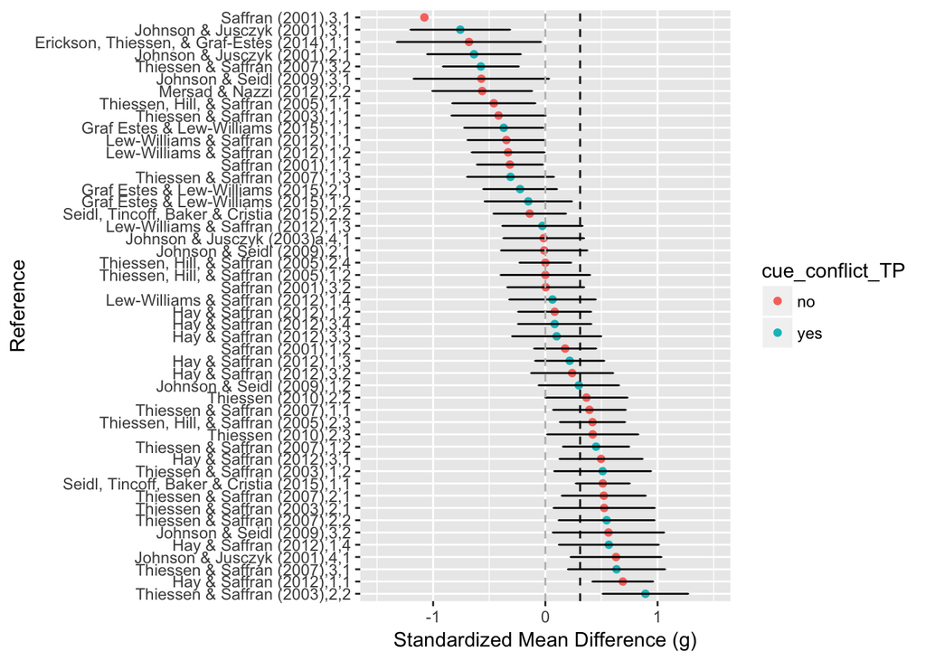

```r
dat <- db %>% rename(cite = short_cite, yi = g_calc, vi = g_var_calc) %>% mutate(study_ref = paste(cite,
    expt_num, same_infant, sep = ",")) %>% filter(cue_conflict_TP != "")
dat$se = sqrt(dat$vi)
dat$lowerci = (-1.96 * dat$se) + dat$yi
dat$upperci = (1.96 * dat$se) + dat$yi

ggplot(dat, aes(y = reorder(study_ref, -yi), x = yi, xmin = lowerci, xmax = upperci)) +
    geom_point(aes(color = cue_conflict_TP)) + geom_errorbarh(height = 0.1) +
    scale_x_continuous(limits = c(-1.5, 1.5), name = "Standardized Mean Difference (g)") +
    ylab("Reference") + geom_vline(xintercept = 0, color = "grey", linetype = "dashed") +
    geom_vline(xintercept = 0.31, color = "black", linetype = "dashed")
```